# Assignment 3: Verify the Claim

Census figures on Philly neighborhoods show inequality, high numbers of whites living in poverty

Author

Katie Steele

Published

September 24, 2026

# Part 1 - Reconstruct

### 1.1 ACS data load

**NoteInstructions**

Pull the ACS data the article appears to rely on. Document:

- Which variable(s) you used and why. Include the variable code.
- Which years and survey you used and why.
- What you had to assume, because the article does not say.
- State clearly whether the two periods the article compares overlap. If they do, say what that means for any conclusion drawn from the comparison.

In this assignment, I attempt to recreate [this 2018 WHYY article](https://whyy.org/articles/new-census-figures-on-philly-neighborhoods-show-inequality-high-numbers-of-whites-living-in-poverty/)’s analysis on changes to poverty rate across Philadelphia. To do so, I pull two variables from the 2006-2010 and 2013-2017 ACS 5-year releases: `B17001_002`, total number of people whose income is below poverty level, and `B17001_001`, total population for whom poverty status is measured. The proportion `B17001_002` / `B17001_001` = `poverty rate`.

I based my choice of ACS releases on WHYY’s; they directly reference both: “The latest data are from a five-year survey between 2013 and 2017. Comparisons reflect changes from the 2006-2010 five-year period.” These two periods do not overlap, which allows for valid significance testing on the differences between the two periods.

The ACS data allow me to compute the poverty rate estimate for each tract in Philadelphia in 2010 and 2017, and to estimate the change in tract poverty rates between the two releases. I further aggregate to the neighborhood level to examine whether the trends cited in the WHYY article hold up. The article does not state what neighborhood boundaries were used for analysis, nor what method was used to match tracts to neighborhoods. I used the latest set of neighborhood boundaries from [OpenDataPhilly](https://opendataphilly.org/datasets/philadelphia-neighborhoods/); this dataset was last updated in April 2024, which suggests that my replicated analysis is unlikely to line up completely with the original WHYY reporting.

```r
# Note: I've been using R since ~2019, so wrote a couple functions in this script to simplify pulls + calculations across the two ACS releases of interest.

pull_tracts <- function(yr){
  get_acs(
    geography = "tract",
    variables = params$VARS,
    state = params$STATE,
    county = params$COUNTY,
    year = yr,
    survey = "acs5"
  ) %>%
  #   # drop tract name
  # select(-NAME) %>%
  # pivot wider so one entry per tract
  pivot_wider(names_from = variable,
              values_from = c(estimate, moe)) %>%
  # rename vars for clarity - using paste0() to avoid hardocoding
  rename(est_denom = paste0("estimate_", params$VARS[2]),
         moe_denom = paste0("moe_", params$VARS[2]),
         est_numer = paste0("estimate_", params$VARS[1]),
         moe_numer = paste0("moe_", params$VARS[1])) %>%

  mutate(pov_rate = est_numer/est_denom,
         pov_rate_moe = moe_prop(est_numer, est_denom,
                                 moe_numer, moe_denom))
}
```

### 1.2 NA examination

**NoteInstructions**

Handle your missing values deliberately. Some tracts will produce NA. Find out why before you decide what to do about them, and say what you decided and why.

The 2010 ACS release produces 7 tracts with 0 population; the 2017 release produces 8, displayed below. Examining the tracts using [Google Data Commons](https://datacommons.org/place/geoId/42101980500), I find that all of the tracts represent nonresidential areas – near the airport, in waterfront areas, or encompassing parks. Each of these tracts are dropped from the analysis because they’ll produce NA values due to the zero denominators.

Tract 9806 (also highlighted below) is the one tract in which residents were surveyed in 2010 but not in 2017; we can see that its population was only 92 in 2010, and it had an extremely high MOE relative to the estimate. This small tract is also dropped to avoid causing trend issues in a potentially sparsely populated neighborhood.

```r
acs5_2010 <- pull_tracts(2010)
acs5_2017 <- pull_tracts(2017)

# check tracts w/ 0 pop in 2010
acs5_2010 %>%
  filter(est_denom == 0) %>%
  select(NAME) %>%
  mutate(NAME = str_remove_all(NAME, "Philadelphia County, Pennsylvania|Census Tract |, ")) %>%
  pull()
```

```
[1] "50"   "9803" "9804" "9805" "9807" "9808" "9809"
```

```r
# check tracts w/ 0 pop in 2017
acs5_2017 %>%
  filter(est_denom == 0) %>%
  select(NAME) %>%
  mutate(NAME = str_remove_all(NAME, "Philadelphia County, Pennsylvania|Census Tract |, ")) %>%
  pull()
```

```
[1] "50"   "9803" "9804" "9805" "9806" "9807" "9808" "9809"
```

```r
# check tract 9806 -- pop present in 2010 but not 2017
# small pop, very high moe relative to est -- will get dropped in merge
acs5_2010 %>%
  filter(str_detect(NAME, "9806"))
```

```
# A tibble: 1 × 8
  GEOID      NAME  est_denom est_numer moe_denom moe_numer pov_rate pov_rate_moe
  <chr>      <chr>     <dbl>     <dbl>     <dbl>     <dbl>    <dbl>        <dbl>
1 421019806… Cens…        92         9        61        14   0.0978        0.138
```

```r
# drop NAs
acs5_2010 <- acs5_2010 %>%
  filter(est_denom != 0)

acs5_2017 <- acs5_2017 %>%
  filter(est_denom != 0)

acs5_2010 <- acs5_2010 %>%
  filter(!str_detect(NAME, "9806"))
```

## 1.3 Neighborhood-level extension

### 1.3.1 Data collection + standardization

To aggregate tracts to the neighborhood level, I downloaded and loaded the [GeoJSON file from OpenDataPhilly](https://opendataphilly.org/datasets/philadelphia-neighborhoods/) which contains the boundaries of 142 Philadelphia neighborhoods. I then pulled the geometries from the 2010 and 2017 ACS releases and used `st_transform()` to standardize the CRS to NAD-83 across each dataset.

```r
hoods <- st_read("assignments/philadelphia-neighborhoods.geojson")

tracts10 <- get_acs(
  geography = "tract",
  variables = params$VARS[2], # denominator var (total pop)
  state = params$STATE,
  county = params$COUNTY,
  year = 2010,
  survey = "acs5",
  geometry = TRUE
) %>%
  filter(estimate != 0 & !str_detect(NAME, "9806")) %>% # drop same NAs
  select(GEOID, geometry)


tracts17 <- get_acs(
  geography = "tract",
  variables = params$VARS[2], # denominator var (total pop)
  state = params$STATE,
  county = params$COUNTY,
  year = 2017,
  survey = "acs5",
  geometry = TRUE
) %>%
  filter(estimate != 0) %>% # drop same NAs
  select(GEOID, geometry)
```

### 1.3.2 Tract <-> neighborhood join

I joined a tract to a neighborhood if the tract’s centroid fell within the neighborhood’s boundaries.

```r
st_crs(hoods)$epsg # 4326
st_crs(tracts10)$epsg # 4269
st_crs(tracts17)$epsg # 4269
hoods <- hoods %>% st_transform(crs = 4269) # convert to match


# *Googled* to find this function after the code below threw a warning/error: degenerate edge
tracts10 <- st_make_valid(tracts10)
tracts17 <- st_make_valid(tracts17)
hoods    <- st_make_valid(hoods)

# create crosswalk for 2010 ACS tracts -> neighborhoodmapping
cross10 <- tracts10 %>%
  distinct(GEOID, geometry) %>%
  st_centroid() %>%
  st_join(hoods, join = st_within) %>%
  st_drop_geometry() %>%
  select(GEOID, MAPNAME) %>%
  rename(neighborhood = MAPNAME)

# create crosswalk for 2017 ACS tracts -> neighborhood mapping
cross17 <- tracts17 %>%
  distinct(GEOID, geometry) %>%
  st_centroid() %>%
  st_join(hoods, join = st_within) %>%
  st_drop_geometry() %>%
  select(GEOID, MAPNAME) %>%
  rename(neighborhood = MAPNAME)


# merge neighborhoods to ACS data
acs5_2010 <- acs5_2010 %>%
  left_join(cross10, by = "GEOID") %>%
  filter(!is.na(neighborhood)) # drop one tract which didn't fall w/in neighborhood

acs5_2017 <- acs5_2017 %>%
  left_join(cross17, by = "GEOID")%>%
  filter(!is.na(neighborhood))
```

# Part 2 - Test

**NoteInstructions**

- Compute the poverty rate and its margin of error.

### 2.1 Neighborhood estimates and MOEs

With each tract assigned to its neighborhood, I aggregated `B17001_001` and `B17001_002` estimates and MOEs up to the neighborhood level and calculated neighborhood poverty rates and MOEs.

```r
# aggregate tracts to neighborhood level
agg_hood <- function(df){
  df %>%
    group_by(neighborhood) %>%
    summarize(
      est_numer = sum(est_numer),
      moe_numer = moe_sum(moe = moe_numer, estimate = est_numer),
      est_denom = sum(est_denom),
      moe_denom = moe_sum(moe = moe_denom, estimate = est_denom),
      n_tracts = n()
    ) %>%
    mutate(pov_rate = est_numer / est_denom,
           pov_rate_moe = moe_prop(est_numer, est_denom, moe_numer, moe_denom))
}

# get neighborhood rates for each ACS release
acs5_2010_hoods <- agg_hood(acs5_2010)
acs5_2017_hoods <- agg_hood(acs5_2017)
```

### 2.2 Neighborhood coefficients of variation

**NoteInstructions**

- Compute the coefficient of variation and flag reliability using the Jurjevich et al. (2018) thresholds.

Here, I calculate the coefficient of variation for each neighborhood estimate. Using Jurjevich et al. (2018) thresholds, I report how many neighborhoods fell into each reliability bucket in each ACS release.

```r
# Add flags according to reliability of estimate
# cv = (SE/estimate) *100
# se = MOE / 1.645
# cv = ((MOE/1.645)/estimate) *100

cv_flag = function(df){
  df %>%
    mutate(cv = ((pov_rate_moe/1.645)/pov_rate) * 100,
         emoji = case_when(
           cv < 12 ~ "😁",
           cv >= 12 & cv <40 ~ "🤨",
           cv >= 40 ~ "🤥"
           ),
         reliability = factor(
           case_when(
           cv < 12 ~ "Reliable",
           cv >= 12 & cv <40 ~ "Somewhat reliable",
           cv >= 40 ~ "Unreliable"
           ),
           # ordered factor for table
           levels = c("Reliable", "Somewhat reliable", "Unreliable"),
           ordered = TRUE
           )
         )
}

acs5_2010_hoods <- cv_flag(acs5_2010_hoods)
acs5_2017_hoods <- cv_flag(acs5_2017_hoods)
```

```r
# Build reliability table
reliability_table <- full_join(
  count(acs5_2010_hoods, emoji, reliability, name = "n_2010"),
  count(acs5_2017_hoods, emoji, reliability, name = "n_2017"),
  by = c("emoji", "reliability")
  ) %>%
  arrange(reliability)

reliability_table %>%
  gt() %>%
  cols_label(
    emoji = "",
    reliability = "Reliability",
    n_2010 = "2010 (n)",
    n_2017 = "2017 (n)"
  ) %>%
  cols_align(align = "left",
             columns = c(emoji, reliability, n_2010, n_2017)) %>%
  tab_header(
    title = "Reliability of neighborhood poverty rate estimates",
    subtitle = "Philadelphia neighborhoods, ACS 2010 and 2017 5-year estimates"
  ) %>%
  tab_source_note(
    "Reliability thresholds follow Jurjevich et al. (2018):"
    ) %>%
  tab_source_note(
    "CV < 12% reliable, 12-40% somewhat reliable, > 40% unreliable."
    )
```

Reliability of neighborhood poverty rate estimates

Philadelphia neighborhoods, ACS 2010 and 2017 5-year estimates

|  | Reliability | 2010 (n) | 2017 (n) |
| --- | --- | --- | --- |
| 😁 | Reliable | 32 | 46 |
| 🤨 | Somewhat reliable | 98 | 92 |
| 🤥 | Unreliable | 11 | 3 |

Reliability thresholds follow Jurjevich et al. (2018):  
CV < 12% reliable, 12-40% somewhat reliable, > 40% unreliable.

We can see that the 2017 estimates were marginally more reliable than the 2010 estimates using the given thresholds.

### 2.3 Neighborhood change in poverty rate

**NoteInstructions**

- Compute the change between the two periods and the margin of error of that change.
- Test whether the change is statistically distinguishable from zero at 90% confidence.
- Report how many tracts show a statistically detectable change and how many do not.

Now I examine the main claims of the article: that poverty rate changed drastically across Philadelphia between the 2006-2010 and 2013-2017 estimates.

```r
# merge two ACS 5 years by neighborhood,
# first selecting columns of interest + renaming w/ yr
acs_trend_hoods <- acs5_2010_hoods %>%
  select(neighborhood, pov_rate, pov_rate_moe,
         est_denom, n_tracts) %>%
  rename(pov_rate_2010 = pov_rate,
         pov_rate_moe_2010 = pov_rate_moe,
         est_denom_2010 = est_denom,
         n_tracts_2010 = n_tracts) %>%
  inner_join(acs5_2017_hoods %>%
              select(neighborhood, pov_rate, pov_rate_moe,
                     est_denom, n_tracts) %>%
              rename(pov_rate_2017 = pov_rate,
                     pov_rate_moe_2017 = pov_rate_moe,
                     est_denom_2017 = est_denom,
                     n_tracts_2017 = n_tracts),
            by = "neighborhood") %>%
  # calculate change to poverty levels
  mutate(diff = pov_rate_2017 - pov_rate_2010,
         diff_moe = sqrt(pov_rate_moe_2017^2 + pov_rate_moe_2010^2))
```

#### **2.3.1 Significance**

Between the two releases, 32 of 142 Philadelphia neighborhoods (~23%) show changes to poverty rate that are statistically significant at the 90% confidence level. Their names are displayed below:

```r
# from class: Z = diff / SE_diff
# SE = MOE / 1.645
# Z = 1.645 * diff / MOE_diff
acs_trend_hoods <- acs_trend_hoods %>%
  mutate(z = 1.645 * diff / diff_moe,
         significant = abs(z) > 1.645) # 90%

# how many neighborhoods are statistically signifcant?
sum(acs_trend_hoods$significant, na.rm = TRUE)
```

```
[1] 32
```

```r
# print neighborhoods of significance
print(acs_trend_hoods %>% filter(significant) %>% select(neighborhood), n = Inf)
```

```
# A tibble: 32 × 1
   neighborhood
   <chr>
 1 Andorra
 2 Bella Vista
 3 Brewerytown
 4 Bridesburg
 5 Burholme
 6 Byberry
 7 Cedarbrook
 8 Center City East
 9 Chinatown
10 Crescentville
11 East Park
12 East Parkside
```

[output cut: 20 more lines]

#### **2.3.2 Plot**

The neighborhoods with significant changes are also plotted below according to the size/direction of their estimated change in poverty rate.

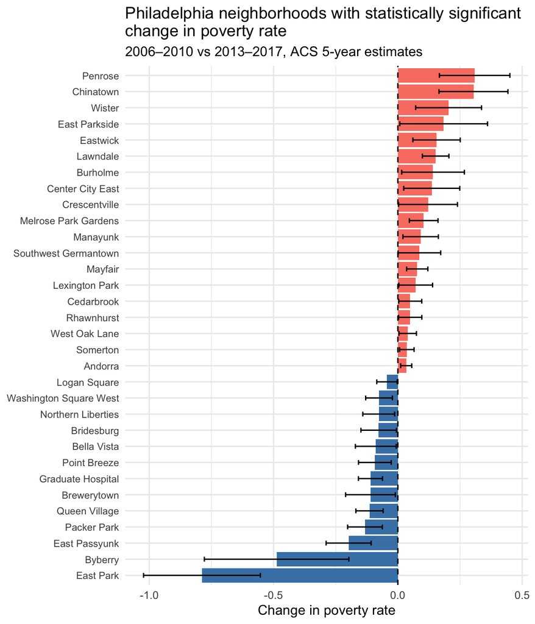

```r
# Visualize with error bars
acs_trend_hoods %>%
  filter(significant) %>%
  #mutate(NAME = str_remove_all(NAME, "Philadelphia County, Pennsylvania|Census Tract|,")) %>%
  ggplot(aes(x = reorder(neighborhood, diff), y = diff)) +
  geom_col(aes(fill = diff > 0),
           show.legend = FALSE,  # added to suppress legend
           ) +
  geom_errorbar(aes(ymin = diff - diff_moe,
                    ymax = diff + diff_moe), width = 0.3) +
  geom_hline(yintercept = 0, linetype = "dashed") +
  coord_flip() +
  #scale_y_continuous(expand = expansion(mult = 0.5)) + # added to space out a bit
  theme_minimal() +
  theme(axis.text.y = element_text(size = 8)) +
  scale_fill_manual(values = c("TRUE" = "salmon",
                               "FALSE" = "steelblue")) + # added to match map below
  labs(title = "Philadelphia neighborhoods with statistically significant\nchange in poverty rate",
       subtitle = "2006–2010 vs 2013–2017, ACS 5-year estimates",
       x = NULL, y = "Change in poverty rate")
```

# Part 3 - Adjudicate

**NoteInstructions**

Sort the article’s claims into three buckets:

- Supported — the data backs this up.
- Not supported — the data contradicts it, or the apparent effect is not distinguishable from noise.
- Cannot be determined — answering would require data or methodological detail the article does not provide and you cannot recover.

### 3.1 Investigating WHYY’s neighborhood-specific claims

```r
acs_trend_hoods %>%
  filter(neighborhood %in% c("Holmesburg",
                             "Eastwick",
                             "Mayfair")) %>%
  select(neighborhood, significant,
         pov_rate_2010, pov_rate_moe_2010,
         pov_rate_2017, pov_rate_moe_2017,
         diff, diff_moe,
         est_denom_2010, est_denom_2017)
```

```
# A tibble: 3 × 10
  neighborhood significant pov_rate_2010 pov_rate_moe_2010 pov_rate_2017
  <chr>        <lgl>               <dbl>             <dbl>         <dbl>
1 Eastwick     TRUE                0.114            0.0511         0.269
2 Holmesburg   FALSE               0.176            0.0548         0.253
3 Mayfair      TRUE                0.112            0.0250         0.190
# ℹ 5 more variables: pov_rate_moe_2017 <dbl>, diff <dbl>, diff_moe <dbl>,
#   est_denom_2010 <dbl>, est_denom_2017 <dbl>
```

#### **3.1.1 Partially supported:**

> “The neighborhood of Eastwick in Southwest Philadelphia, near Philadelphia International Airport, showed the greatest poverty-rate increase of any community, rocketing from 12 percent during 2006-10 to 26 percent in the newest survey.”

Eastwick’s poverty rate spiked from roughly 12 percent in 2006-2010 to 26 percent in 2013-2017, and this change was statistically significant at the 90% confidence level.

```r
acs_trend_hoods %>%
  filter(significant) %>%
  mutate(ci = paste0("[", round(diff - diff_moe, 3), ", ",
                     round(diff + diff_moe, 3), "]")) %>%
  select(neighborhood, diff, diff_moe, ci,
         pov_rate_2010, pov_rate_2017,
         est_denom_2010, est_denom_2017) %>%
  arrange(desc(diff)) %>%
  head(5)
```

```
# A tibble: 5 × 8
  neighborhood   diff diff_moe ci     pov_rate_2010 pov_rate_2017 est_denom_2010
  <chr>         <dbl>    <dbl> <chr>          <dbl>         <dbl>          <dbl>
1 Penrose       0.309   0.142  [0.16…        0.0405         0.349           5999
2 Chinatown     0.304   0.139  [0.16…        0.0719         0.376           1919
3 Wister        0.204   0.132  [0.07…        0.385          0.590           3552
4 East Parkside 0.184   0.177  [0.00…        0.297          0.482           3271
5 Eastwick      0.156   0.0953 [0.06…        0.114          0.269           2718
# ℹ 1 more variable: est_denom_2017 <dbl>
```

But sorting the dataframe on the size of increase, we see that at least 4 other communities had larger increases to poverty rate between 2006-2010 and 2013-2017 than Eastwick; the ~15.6 point increase I find there is smaller than the significant increases I find in Penrose (+30.9pp), Chinatown (+30.4pp), Wister (+20.4pp), and East Parkside (+18.4pp). That said, each neighborhood is relatively small, and the estimates each have a large relative MOE, so it is possible that Eastwick did have the highest increase of any community – the high end of its confidence interval falls within Penrose and Chinatown’s confidence intervals, for example – but cannot be confirmed with certainty.

#### **3.1.2 Not supported:**

> “The more detailed survey released on Thursday revealed that the poverty rates in 22 majority-white neighborhoods in Philadelphia increased between the 2006-10 survey and the 2013-17 survey … Holmesburg recorded the highest increase, from 2 percent to 19 percent.”

Not only do my numbers not match up here – I find Holmesburg had a baseline 17 percent (+/- 5 percent) poverty rate in 2010 and a 25 percent (+/-7 percent) poverty rate in 2017 – I also do not find that the change is statistically significant at the 90% level. Interestingly, WHYY’s own interactive `Where Poverty Has Increased in Philadelphia` map shows different estimates for Holmesburg (18 percent -> 22 percent) than the ones that appear in the text; the map estimates do roughly agree with my findings.

> “[In Mayfair], the poverty rate rose from 1 percent to 14 percent.”

I do find that the increase in poverty rate in Mayfair is significant at the 90% confidence level, but my estimates don’t line up. I find that the poverty rate increased from roughly 11 percent -> 19 percent, while the article’s text cites an increase from 1 percent -> 14 percent. Again, the interactive map shows much closer estimates to mine, of 12 percent -> 18 percent.

#### **3.1.3 Cannot be determined:**

> “Fairhill in North Philadelphia registered a stunning 61 percent poverty rate.”

```r
any(hoods$MAPNAME == "Fairhill")
```

```
[1] TRUE
```

```r
any(acs_trend_hoods$neighborhood == "Fairhill")
```

```
[1] FALSE
```

My aggregated tract -> neighborhood dataset does not contain any entry for Fairhill, which receives a lot of attention in this article – so I can’t confirm whether the 2017 ACS 5-year showed that 61% of its residents were living in poverty.

This leads me to believe that WHYY used different neighborhood boundaries, or a different methodology for matching tracts to neighborhoods, than I did, which could also be driving some of the discrepancies between my findings and theirs. I joined a tract to a neighborhood if its centroid fell within the neighborhood, but a different approach (e.g., distance or % coverage) would produce different results.

I considered whether WHYY might have been using the 2016 and 2017 ACS 1-year estimates for white poverty to compute the estimates included in the text (because they’re so different from mine), but the 1-year ACS isn’t released at the tract level and I don’t think they could pull neighborhood-level estimates from them as a result. Since the neighborhoods are referenced as majority-white, I also don’t think that the 1-year white poverty rate estimates in Mayfair/Holmesburg would be 10 to 15 points off the total poverty rate from the 5-year estimates.

It seems more likely that there was some transcription error in the article writeup, given that the 2010 and 2017 numbers in the interactive map align much more closely with my own findings and that all four of those estimates disagree with the text itself.

### 3.2 Additional viz: Neighborhood-level trend map

Below, I attempt to replicate the article’s `Where Poverty Has Increased in Philadelphia` map, referenced above, and I adjust it to reflect only the neighborhoods where findings were significant at the 90% confidence level.

Since the WHYY map appears to differentiate between large and more moderate changes to poverty rate, I set my own threshold to separate significant neighborhoods – first, grouping by the direction of change, then finding the median change in poverty rate among the neighborhoods in each group. Neighborhoods with a greater absolute change than the absolute median change in their group are shaded darker to reflect larger changes; others are shaded lighter to reflect smaller changes. All other neighborhoods (including NA areas like those around the airport) are shaded grey.

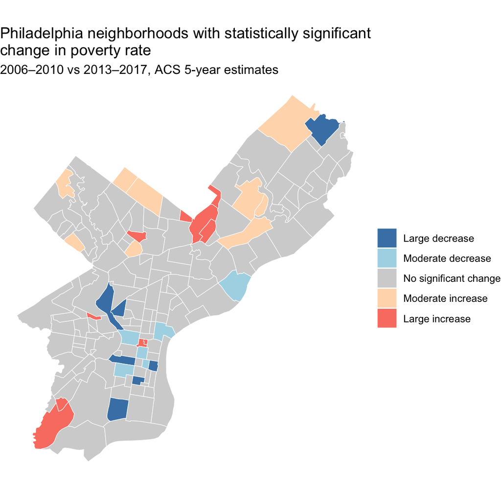

```r
# create threshold for large vs. moderate changes
thresholds <- acs_trend_hoods %>% filter(significant) %>%
  group_by(sign(diff)) %>%
  summarize(threshold = quantile(diff, 0.5))

for_map <- hoods %>%
  left_join(acs_trend_hoods, by = c("MAPNAME" = "neighborhood")) %>%
  # not significant or any NA tracts/neighborhoods (e.g. airport or parks) will get grayed out
  mutate(severity = factor(
    case_when(!significant | is.na(significant) ~ "No significant change",
              diff >= thresholds$threshold[2] ~ "Large increase",
              diff > 0 ~ "Moderate increase",
              diff <= thresholds$threshold[1] ~ "Large decrease",
              diff < 0 ~ "Moderate decrease"),
    levels = c("Large decrease",
               "Moderate decrease",
               "No significant change",
               "Moderate increase",
               "Large increase")))

ggplot(for_map) +
  geom_sf(aes(fill = severity), color = "white") +
  scale_fill_manual(
    values = c("steelblue", "lightblue",
               "lightgray",
               "peachpuff", "salmon"),
    name = NULL ) + # googled to find how to suppress this
  theme_void() +
  theme(legend.position = "right",) +
  labs(title = "Philadelphia neighborhoods with statistically significant\nchange in poverty rate",
       subtitle = "2006–2010 vs 2013–2017, ACS 5-year estimates")
```

#### **3.2.1 Second attempt, with neighborhood names included**

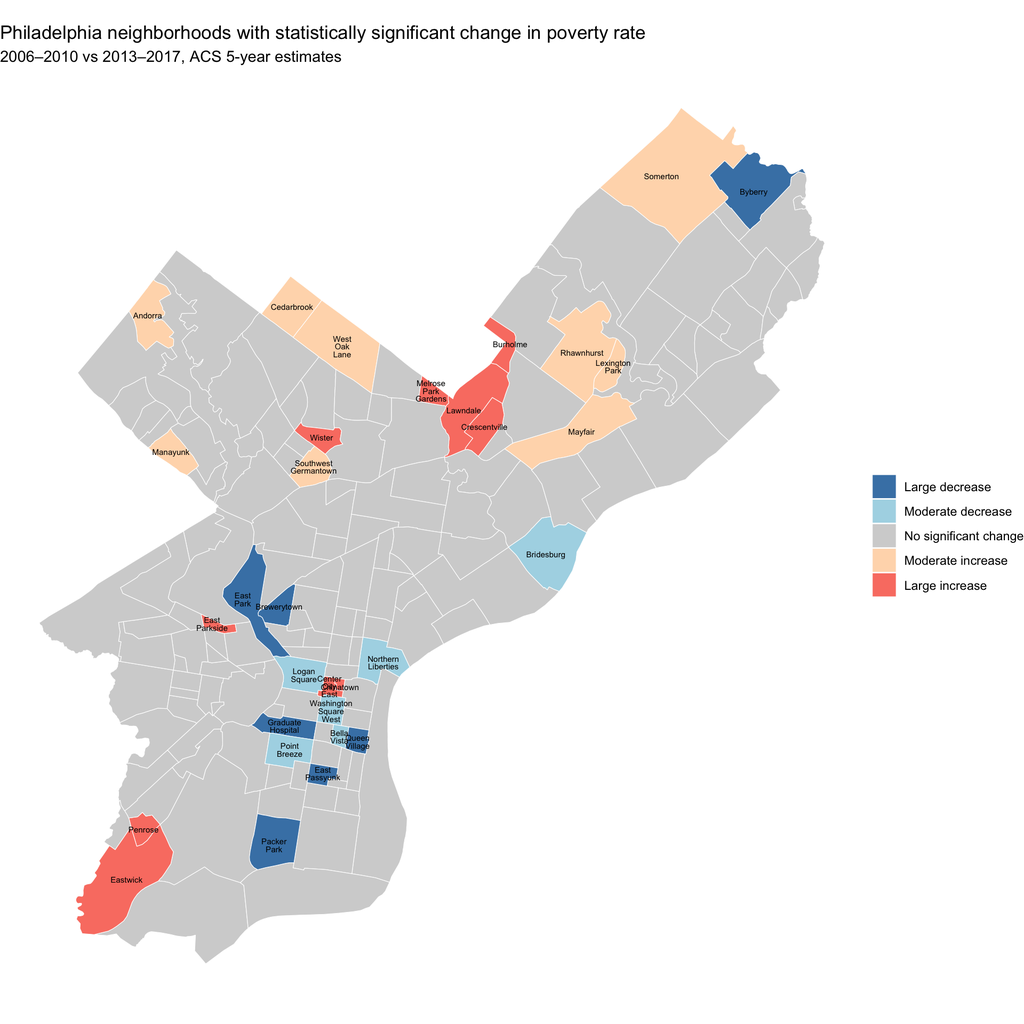

```r
# Plot with neighborhood names --
ggplot(for_map) +
  geom_sf(aes(fill = severity), color = "white", linewidth = 0.2) +
  geom_sf_text(
  data = for_map %>% filter(significant),
  aes(label = str_wrap(MAPNAME, width = 6)),
  size = 2,
  color = "black",
  lineheight = 0.8) +
  scale_fill_manual(
    values = c("steelblue", "lightblue",
               "lightgray",
               "peachpuff", "salmon"),
    name = NULL ) + # googled to find how to suppress this
  theme_void() +
  theme(legend.position = "right",) +
  labs(title = "Philadelphia neighborhoods with statistically significant change in poverty rate",
       subtitle = "2006–2010 vs 2013–2017, ACS 5-year estimates")
```

I used geom_sf_text with str_wrap() to add the text to the plot, but couldn’t get it to cooperate very well given all the overlaps around Center City; I still had to make the font size tiny/unreadable. Google suggested ggrepel might help, but I’m not familiar with the package, so I ended here.

# Part 4 - Rewrite

**NoteInstructions**

Rewrite the article’s central paragraph so that it is defensible given what you found. Keep it readable — this is for a general audience, not a methods section. You may not simply add a disclaimer; the rewrite should say something substantive and true.

The more detailed Census data released Thursday reveals a sharp rise in poverty across many Philadelphia communities between the 2006-2010 and 2013-2017 survey periods. Poverty climbed in many of the city’s predominantly white neighborhoods; in Mayfair, it rose from roughly 11 to 19 percent. In Eastwick, near the Philadelphia International Airport – a neighborhood that has seen significant growth in its African immigrant population in recent years – the poverty rate more than doubled, from about 11 percent to 27 percent. And increasing poverty touched other communities in the city; the poverty rate in neighborhoods like Chinatown and Penrose appears to have climbed by about 30 percentage points, though the data leave uncertainty about the exact size – anywhere from roughly 16 to 45 percentage points.

# (+) Part 5 - Tract-level analysis

I’ve also included my original analysis of Census tracts below. I highlighted my neighborhood analysis for the main assignment since it tied more directly to the WHYY article, but I used the same logic to run the analysis at the tract level without the final aggregation.

**Show tract-level analysis**

*Note: My assignment was getting really crowded (and repetitive) with both my neighborhood and tract-level analyses, so I Googled how to use HTML to hide a full section by default.*

### Coefficient of Variation

```r
# Add flags according to reliability of estimate
# cv = (SE/estimate) *100
# se = MOE / 1.645
# cv = ((MOE/1.645)/estimate) *100

cv_flag = function(df){
  df %>%
    mutate(cv = ((pov_rate_moe/1.645)/pov_rate) * 100,
         emoji = case_when(
           cv < 12 ~ "😁",
           cv >= 12 & cv <40 ~ "🤨",
           cv >= 40 ~ "🤥"
           ),
         reliability = factor(
           case_when(
           cv < 12 ~ "Reliable",
           cv >= 12 & cv <40 ~ "Somewhat reliable",
           cv >= 40 ~ "Unreliable"
           ),
           # ordered factor for table
           levels = c("Reliable", "Somewhat reliable", "Unreliable"),
           ordered = TRUE
           )
         )
}

acs5_2010 <- cv_flag(acs5_2010)
acs5_2017 <- cv_flag(acs5_2017)
```

```r
# Build reliability table
reliability_table <- full_join(
  count(acs5_2010, emoji, reliability, name = "n_2010"),
  count(acs5_2017, emoji, reliability, name = "n_2017"),
  by = c("emoji", "reliability")
  ) %>%
  arrange(reliability)

reliability_table %>%
  gt() %>%
  cols_label(
    emoji = "",
    reliability = "Reliability",
    n_2010 = "2010 (n)",
    n_2017 = "2017 (n)"
  ) %>%
  cols_align(align = "left",
             columns = c(emoji, reliability, n_2010, n_2017)) %>%
  tab_header(
    title = "Reliability of tract poverty rate estimates",
    subtitle = "Philadelphia Census tracts, ACS 2010 and 2017 5-year estimates"
  ) %>%
  tab_source_note(
    "Reliability thresholds follow Jurjevich et al. (2018):"
    ) %>%
  tab_source_note(
    "CV < 12% reliable, 12-40% somewhat reliable, > 40% unreliable."
    )
```

Reliability of tract poverty rate estimates

Philadelphia Census tracts, ACS 2010 and 2017 5-year estimates

|  | Reliability | 2010 (n) | 2017 (n) |
| --- | --- | --- | --- |
| 😁 | Reliable | 11 | 22 |
| 🤨 | Somewhat reliable | 320 | 331 |
| 🤥 | Unreliable | 44 | 22 |

Reliability thresholds follow Jurjevich et al. (2018):  
CV < 12% reliable, 12-40% somewhat reliable, > 40% unreliable.

### Change in poverty rate

```r
# merge two ACS releases by tract,
# first selecting columns of interest + renaming w/ yr
acs_trend <- acs5_2010 %>%
  select(GEOID, NAME, pov_rate, pov_rate_moe) %>%
  rename(pov_rate_2010 = pov_rate,
         pov_rate_moe_2010 = pov_rate_moe) %>%
  inner_join(acs5_2017 %>%
              select(GEOID, pov_rate, pov_rate_moe) %>%
              rename(pov_rate_2017 = pov_rate,
                     pov_rate_moe_2017 = pov_rate_moe),
            by = "GEOID")

acs_trend <- acs_trend %>%
  mutate(diff = pov_rate_2017 - pov_rate_2010,
         diff_moe = sqrt(pov_rate_moe_2017^2 + pov_rate_moe_2010^2))
```

#### Significance

```r
# from class: Z = diff / SE_diff
# SE = MOE / 1.645
# Z = 1.645 * diff / MOE_diff
acs_trend <- acs_trend %>%
  mutate(z = 1.645 * diff / diff_moe,
         significant = abs(z) > 1.645) # 90%

# how many tracts are statistically signifcant?
sum(acs_trend$significant, na.rm = TRUE)
```

```
[1] 63
```

#### Mean difference

```r
# what's the mean difference among the tracts that show significance?
print(paste("Mean difference among tracts with statistically significant change:", round(mean(acs_trend$diff[acs_trend$significant == TRUE]), 4)))
```

```
[1] "Mean difference among tracts with statistically significant change: 0.0037"
```

The mean difference in poverty rate among tracts with a statistically significant change between the 2010 and 2017 ACS releases is near zero. Below, we can see that the directional effects roughly cancel out among tracts with statistically significant changes, which drives the very small (ungrouped) mean difference.

```r
# did increases/decreases cancel out
acs_trend %>%
  filter(significant) %>%
  mutate(direction = if_else(diff > 0, "increase", "decrease")) %>%
  group_by(direction) %>%
  summarise(n = n(), mean_change = mean(diff))
```

```
# A tibble: 2 × 3
  direction     n mean_change
  <chr>     <int>       <dbl>
1 decrease     27      -0.202
2 increase     36       0.158
```

#### Plot

The tracts with significant changes are plotted below.

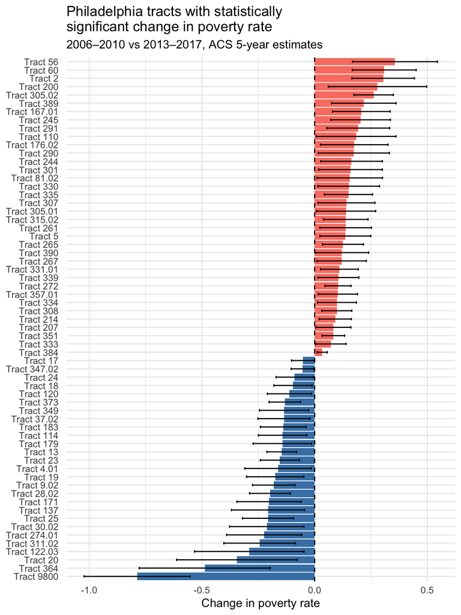

```r
acs_trend %>%
  filter(significant) %>%
  mutate(NAME = str_remove_all(NAME, "Philadelphia County, Pennsylvania|Census |,")) %>%
  ggplot(aes(x = reorder(NAME, diff), y = diff)) +
  geom_col(aes(fill = diff > 0),
           show.legend = FALSE,  # added to suppress legend
           ) +
  geom_errorbar(aes(ymin = diff - diff_moe,
                    ymax = diff + diff_moe), width = 0.3) +
  geom_hline(yintercept = 0, linetype = "dashed") +
  coord_flip() +
  #scale_y_continuous(expand = expansion(mult = 0.5)) + # added to space out a bit
  theme_minimal() +
  scale_fill_manual(values = c("TRUE" = "salmon",
                               "FALSE" = "steelblue")) + # added to match map: red = bad (increase in pov), blue = better
  labs(title = "Philadelphia tracts with statistically \nsignificant change in poverty rate",
       subtitle = "2006–2010 vs 2013–2017, ACS 5-year estimates",
       x = NULL, y = "Change in poverty rate")
```